# Comparison of `for` loops from various programming languages

## Introduction

In this activity, I show you the programming languages that can be used in computing with the use of `for` loops.

Note that not all the programming languages are listed in this example because these are all the programming languages I know that can be exported into R.

Here are the list of languages will be used in this activity:

1. C
   - C is maybe the easiest *compiled* language to learn. It is so easy to compile a C code into R.
2. C++
   - Despite its reputation for complexity, leveraging tools like Rcpp and its APIs makes writing C++ code more accessible. Plus, exporting C++ code into the R environment is a breeze, even I, who sometimes write a bad code, can write a C++ code and it is so easy to export a C++ code into R environment.
   - Compared to C, compilation in C++ might take a bit longer due to various factors.
   - with the Rcpp namespace, you can seamlessly integrate C++ features like *NumericVector* and *DataFrame*, mirroring R’s class system.
3. Julia
   - Julia shares similarities with C in that it’s a compiled language, effectively addressing the “2 language problem” by eliminating the need for separate languages like C, C++, or FORTRAN APIs.
   - Julia is a JIT compiled and it is able to be both fast and easy to read.
4. Rust
   - Rust, akin to C/C++, prioritizes memory safety.
   - Preparing to compile Rust code in R involves installing necessary Build Tools and rustc cargo via the terminal.
5. FORTRAN
   - Despite its age, FORTRAN remains indispensable in the realm of computing, boasting speed comparable to C/C++.
   - It’s still widely used as *source* code for R packages, *fAsianOptions* as its example.
6. R
   - While maybe R isn’t exclusively utilized for computing, it’s a statistical computing language widely embraced in statistical analysis.
   - With R, it is so easy to conduct a pure data science like data manipulation and visulizations, thanks to the libraries, such as *dplyr* and *ggplot2*, and to integrate “structured” databases with *DBI* and *dbplyr*.
7. Python
   - Python is an effective general purpose language that can be even used in statistics or any fields of computing.

## Approximating $\pi$

It took hundreds of years to precisely approximate the $\pi$.

I used the Leibniz formula to approximate $\pi$. It came from an alternating series, a power series of $\frac{1}{x^2+1}$.

This is how Leibniz formula looks like:

$$\pi=4\sum_{k = 0}^{\infty} {\frac{(-1)^k}{2k + 1}}$$

We need to adjust a little bit for the programming languages that starts with index-1, like R, Julia and FORTRAN.

This is how Leibniz formula looks like:

**C**

If your purpose is a language for fast computation within R, C is maybe easier than C++ but in order this to be working and exportable, the inputs and outputs of the computation were stored in the memory address, a.k.a. the pointers.

```c
#include <stdio.h>

void pi_approx_c(int *n, double *result) {
  double pi_4 = 0;
  double sign = 1;

  for (int i = 0; i < *n; i++) {
    pi_4 += sign / (2 * i + 1);
    sign *= -1;
  }

  *result = 4 * pi_4;
}
```

```
gcc  -I"D:/R GUI/R-4.3.3/R-4.3.3/include" -DNDEBUG     -I"C:/rtools43/x86_64-w64-mingw32.static.posix/include"     -O2 -Wall  -mfpmath=sse -msse2 -mstackrealign  -c c185471b0210.c -o c185471b0210.o
gcc -shared -s -static-libgcc -o c185471b0210.dll tmp.def c185471b0210.o -LC:/rtools43/x86_64-w64-mingw32.static.posix/lib/x64 -LC:/rtools43/x86_64-w64-mingw32.static.posix/lib -LD:/R GUI/R-4.3.3/R-4.3.3/bin/x64 -lR
```

In order to wrap the C code into R, use `.C` and then extract the result via `$res`.

```r
pi_approx_c <- function(n) {
  res <- .C("pi_approx_c", as.integer(n), res=numeric(1))$res
  return(res)
}

pi_approx_c(1e5)
```

```
[1] 3.141583
```

**C++**

Here, the C++ code is way similar to the C code except, we don’t need to use *pointers* in order share the results in a memory address, instead we only write the C++ code in a standard way. Like I said, using Rcpp, the C++ code is so easy to be exported, as long as we made it to be error-free.

After compiling, the `pi_approx_cpp` function will be exported by `// [[Rcpp::export]]` attributes and saved into R Global Environment directly.

```cpp
#include <Rcpp.h>
using namespace Rcpp;

// [[Rcpp::export]]
double pi_approx_cpp(int n) {
  double pi_4 = 0;
  double sign = 1;

  for (int i = 0; i < n; i++) {
    pi_4 += sign / (2 * i + 1);
    sign *= -1;
  }

  return 4 * pi_4;
}

/***R
pi_approx_cpp(1e5)
*/
```

**Julia**

As you can see, we only write few codes, unlike in C/C++, to approximate the $\pi$

```julia
function pi_approx_jl(n)
    pi_4 = 0.0
    sign = 1.0
    for i in 1:n
        pi_4 += sign / (2*i - 1)
        sign *= -1
    end
    return 4 * pi_4
end
```

```
pi_approx_jl (generic function with 1 method)
```

With *JuliaCall*, you can wrap the Julia function into R via `julia_eval`. But there are few other ways to call it, but I found `julia_eval` more convenient.

(Note: If you are already familiar with `reticulate`, this is the same as `py_eval`)

```r
pi_approx_jl <- JuliaCall::julia_eval("pi_approx_jl")
pi_approx_jl(1e5)
```

```
[1] 3.141583
```

**Rust**

Here, we use the `extendr` and `#[extendr]` attribute API to write a Rust code and compile it into R, just like we did with Rcpp to compile the C++ code into R

```rust
use extendr_api::prelude::*;

#[extendr]
fn pi_approx_rs(n: i32) -> f64 {
    let mut pi_4 = 0.0;
    let mut sign = 1.0;

    for i in 0..n {
        pi_4 += sign / (2 * i + 1) as f64;
        sign *= -1.0;
    }

    4.0 * pi_4
}
```

After compiling, just like C++, the `pi_approx_rs` function in Rust will be wrapped and saved into R Global Environment directly.

```r
pi_approx_rs(1e5)
```

```
[1] 3.141583
```

**FORTRAN**

Maybe FORTRAN is fast, but the solution is more boilerplate, although for me it is more readable compared to C/C++. Just like C, we need the result to be store in memory address.

If you use old FORTRAN version, you might need to CAPITALIZE the FORTRAN program. But we use the ’95 version of FORTRAN so we don’t need to CAPITALIZE the program.

```
subroutine pi_approx(n, result)
    implicit none
    integer, intent(in) :: n
    real(8), intent(out) :: result
    integer :: i
    real(8) :: pi_4, sign

    pi_4 = 0.0
    sign = 1.0

    do i = 1, n
        pi_4 = pi_4 + sign / (2 * i - 1)
        sign = sign * (-1.0)
    end do

    result = 4 * pi_4
end subroutine pi_approx
```

```
gfortran      -O2  -mfpmath=sse -msse2 -mstackrealign  -c  f9518542ef967ec.f95 -o f9518542ef967ec.o
gcc -shared -s -static-libgcc -o f9518542ef967ec.dll tmp.def f9518542ef967ec.o -LC:/rtools43/x86_64-w64-mingw32.static.posix/lib/x64 -LC:/rtools43/x86_64-w64-mingw32.static.posix/lib -lgfortran -lm -lquadmath -LD:/R GUI/R-4.3.3/R-4.3.3/bin/x64 -lR
```

Just like C, but instead, in order to natively call the FORTRAN code into R, use `.Fortran` and then extract the result via `$result`.

```r
pi_approx_fortran <- function(n) {
  result <- .Fortran("pi_approx", as.integer(n), result=double(1))$result
  return(result)
}

pi_approx_fortran(1e5)
```

```
[1] 3.141583
```

**R**

R is so close to be functional programming and to be Domain Specific Language (or DSL). It is so functional, you need to use `<- function()` to define a function and I sometimes agree that this is ugly but hey it works! This is just my opinion.

R is already a default language in RStudio, so the function we define is already callable in R Global Environment.

```r
pi_approx_r <- function(n) {
  pi_4 <- 0
  sign <- 1

  for (i in 1:n) {
    pi_4 <- pi_4 + sign / (2*i - 1)
    sign <- sign * -1
  }

  return(4 * pi_4)
}

pi_approx_r(1e5)
```

```
[1] 3.141583
```

**Python**

R and Python has so much similarities, except Python is more onto general purpose language.

```python
def pi_approx_py(n):
    n = int(n)
    pi_4 = 0
    sign = 1

    for i in range(n):
        pi_4 += sign / (2 * i + 1)
        sign *= -1
    return pi_4 * 4
```

The defined function in Python is also callable. Using `py` module in `reticulate` package, you can easily interact with any Python objects in Python module.

```r
pi_approx_py <- reticulate::py$pi_approx_py
pi_approx_py(1e5)
```

```
[1] 3.141583
```

**Benchmarks**

The benchmarks are the same when I capture the date and time, similar to `Sys.time` in R. For example, when I run the Python code for $\pi$ approximation (same code as example) and benchmark it with `time` module for the first time, I got a difference of 17 seconds. Plus, the `mark` function from `bench` package is so precise that I use this package everytime when I benchmark the codes.

```r
pi_approx_bm <- bench::mark(
  C = pi_approx_c(1e8),
  Cpp = pi_approx_cpp(1e8),
  Julia = pi_approx_jl(1e8),
  Rust = pi_approx_rs(1e8),
  FORTRAN = pi_approx_fortran(1e8),
  R = pi_approx_r(1e8),
  Python = pi_approx_py(1e8),
  check = F
)
pi_approx_bm
```

```
# A tibble: 7 × 6
  expression      min   median `itr/sec` mem_alloc `gc/sec`
  <bch:expr> <bch:tm> <bch:tm>     <dbl> <bch:byt>    <dbl>
1 C          149.03ms 150.46ms    6.64     16.46KB        0
2 Cpp        149.37ms 150.53ms    6.65      7.67KB        0
3 Julia      405.06ms 406.75ms    2.46      5.73KB        0
4 Rust          1.13s    1.13s    0.885      4.8KB        0
5 FORTRAN    148.76ms 149.78ms    6.67     16.46KB        0
6 R             9.91s    9.91s    0.101         0B        0
7 Python       20.06s   20.06s    0.0499    4.98KB        0
```

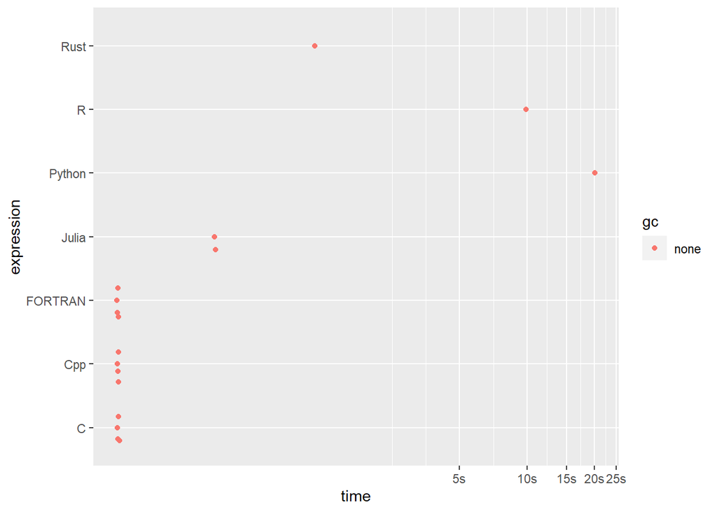

```r
pi_approx_bm |> plot()
```

## Recursive Fibonacci Sequence

Same procedure as approximating the $\pi$, compile and then compile

**C**

```c
#include <R.h>
#include <Rinternals.h>

void fib_c(int *n, int *seq) {
    seq[0] = 0;
    if (*n > 0) {
        seq[1] = 1;
        for (int i = 2; i <= *n; ++i) {
            seq[i] = seq[i - 1] + seq[i - 2];
        }
    }
}
```

```
gcc  -I"D:/R GUI/R-4.3.3/R-4.3.3/include" -DNDEBUG     -I"C:/rtools43/x86_64-w64-mingw32.static.posix/include"     -O2 -Wall  -mfpmath=sse -msse2 -mstackrealign  -c c18545d9423aa.c -o c18545d9423aa.o
gcc -shared -s -static-libgcc -o c18545d9423aa.dll tmp.def c18545d9423aa.o -LC:/rtools43/x86_64-w64-mingw32.static.posix/lib/x64 -LC:/rtools43/x86_64-w64-mingw32.static.posix/lib -LD:/R GUI/R-4.3.3/R-4.3.3/bin/x64 -lR
```

```r
fib_c <- function(n) {
  seq <- integer(n + 1)
  .C("fib_c", n = as.integer(n), seq = as.integer(seq))$seq
}
fib_c(10)
```

```
 [1]  0  1  1  2  3  5  8 13 21 34 55
```

**C++**

```cpp
#include <Rcpp.h>
using namespace Rcpp;

// [[Rcpp::export]]
IntegerVector fib_cpp(int n){
  IntegerVector fibSequence(n + 1);
  fibSequence[0] = 0;
  if (n > 1) {
    fibSequence[1] = 1;
    for (int i = 2; i <= n; ++i) {
      fibSequence[i] = fibSequence[i - 1] + fibSequence[i - 2];
    }
  }
  return fibSequence;

}


/***R
fib_cpp(10)
*/
```

**Julia**

```julia
function fib_jl(n::Int)
  fib = Int[]
  push!(fib, 0)
  push!(fib, 1)


  for i in 3:n
      push!(fib, fib[i - 1] + fib[i - 2])
  end

  return fib
end
```

```
fib_jl (generic function with 1 method)
```

```r
fib_jl <- JuliaCall::julia_eval("fib_jl")
fib_jl(10L)
```

```
 [1]  0  1  1  2  3  5  8 13 21 34
```

**Rust**

```rust
use extendr_api::prelude::*;
use std::collections::HashMap;

fn fibonacci(n: i32, memo: &mut HashMap<i32, i32>) -> i32 {
    if let Some(&result) = memo.get(&n) {
        return result;
    }

    let result = if n <= 1 {
        n
    } else {
        fibonacci(n - 1, memo) + fibonacci(n - 2, memo)
    };

    memo.insert(n, result);
    result
}

#[extendr]
fn fib_rs(n: i32) -> Vec<i32> {
    let mut sequence = vec![];
    let mut memo = HashMap::new();

    for i in 0..n + 1 {
        sequence.push(fibonacci(i, &mut memo));
    }

    sequence
}
```

```r
fib_rs(10)
```

```
 [1]  0  1  1  2  3  5  8 13 21 34 55
```

**FORTRAN**

```
subroutine fib_f(n, fib)
    integer, intent(in) :: n
    integer, intent(out) :: fib(n)
    integer :: i

    fib(1) = 0
    fib(2) = 1

    do i = 3, n + 1
        fib(i) = fib(i-1) + fib(i-2)
    end do

end subroutine fib_f
```

```
gfortran      -O2  -mfpmath=sse -msse2 -mstackrealign  -c  f9518543ce8ee0.f95 -o f9518543ce8ee0.o
gcc -shared -s -static-libgcc -o f9518543ce8ee0.dll tmp.def f9518543ce8ee0.o -LC:/rtools43/x86_64-w64-mingw32.static.posix/lib/x64 -LC:/rtools43/x86_64-w64-mingw32.static.posix/lib -lgfortran -lm -lquadmath -LD:/R GUI/R-4.3.3/R-4.3.3/bin/x64 -lR
```

```r
fib_fortran <- function(n) {
  n <- n + 1
  .Fortran("fib_f", as.integer(n), fib = integer(n))$fib
}
fib_fortran(10)
```

```
 [1]  0  1  1  2  3  5  8 13 21 34 55
```

**R**

```r
fib_r <- function(n) {
  fib <- integer(n + 1)
  fib[1] <- 0
  fib[2] <- 1
  for (i in 3:(n+1)) {
    fib[i] <- fib[i - 1] + fib[i - 2]
  }
  return(fib)
}

fib_r(10)
```

```
 [1]  0  1  1  2  3  5  8 13 21 34 55
```

**Python**

```python
def fib_p(n):
    n = int(n)
    fib_seq = [0, 1]
    for i in range(2, n + 1):
        fib_seq.append(fib_seq[-1] + fib_seq[-2])
    return fib_seq
```

```r
fib_py <- reticulate::py$fib_p
fib_py(10)
```

```
 [1]  0  1  1  2  3  5  8 13 21 34 55
```

**Benchmarks**

```r
bench::mark(
  C = fib_c(40),
  Cpp = fib_cpp(40),
  Julia = fib_jl(41L),
  Rust = fib_rs(40),
  FORTRAN = fib_fortran(40),
  R = fib_r(40),
  Python = fib_py(40),
  check = F
)
```

```
# A tibble: 7 × 6
  expression      min   median `itr/sec` mem_alloc `gc/sec`
  <bch:expr> <bch:tm> <bch:tm>     <dbl> <bch:byt>    <dbl>
1 C             2.5µs    2.8µs   218149.   19.23KB     21.8
2 Cpp           1.5µs    1.8µs   276748.    6.84KB      0
3 Julia        10.1µs   10.9µs    83730.    4.89KB      0
4 Rust         67.9µs   69.7µs    13241.    5.02KB      0
5 FORTRAN       2.7µs      3µs   279491.   17.73KB      0
6 R             7.8µs    8.8µs    97832.      592B      0
7 Python       51.6µs   55.5µs    15556.     5.2KB      0
```

### C

```c
#include <R.h>
#include <Rinternals.h>

void fib_c(int *n, int *seq) {
    seq[0] = 0;
    if (*n > 0) {
        seq[1] = 1;
        for (int i = 2; i <= *n; ++i) {
            seq[i] = seq[i - 1] + seq[i - 2];
        }
    }
}
```

```
gcc  -I"D:/R GUI/R-4.3.3/R-4.3.3/include" -DNDEBUG     -I"C:/rtools43/x86_64-w64-mingw32.static.posix/include"     -O2 -Wall  -mfpmath=sse -msse2 -mstackrealign  -c c18542ec77e28.c -o c18542ec77e28.o
gcc -shared -s -static-libgcc -o c18542ec77e28.dll tmp.def c18542ec77e28.o -LC:/rtools43/x86_64-w64-mingw32.static.posix/lib/x64 -LC:/rtools43/x86_64-w64-mingw32.static.posix/lib -LD:/R GUI/R-4.3.3/R-4.3.3/bin/x64 -lR
```

```r
fib_c <- function(n) {
  seq <- integer(n + 1)
  .C("fib_c", n = as.integer(n), seq = as.integer(seq))$seq
}
fib_c(10)
```

```
 [1]  0  1  1  2  3  5  8 13 21 34 55
```

### C++

```cpp
#include <Rcpp.h>
#include <random>
#include <cmath>

// [[Rcpp::depends(Rcpp)]]

using namespace Rcpp;

// Function to estimate pi using Buffon's needle experiment
// [[Rcpp::export]]
double estimatePi(double n) {
    double l = 0.9;
    double p = 0;
    std::random_device rd;
    std::mt19937 gen(rd());
    std::uniform_real_distribution<double> dis_angle(0.0, 360.0);
    std::uniform_real_distribution<double> dis_x(0.0, 1.0);

    for (long i = 0; i < n; i++) {
        double k = dis_angle(gen);  // random angle
        double x = dis_x(gen);      // random x (0 to 1)
        double y = (l / 2) * sin(k * M_PI / 180);  // Convert angle to radians

        if (x <= y) {
            p++;  // Increment only if the condition is met
        }
    }

    double pi = n / p;  // Divide by p, not l

    return pi;
}
```

[output not shown]

### Julia

```julia
function fib_jl(n::Int)
  fib = Int[]
  push!(fib, 0)
  push!(fib, 1)


  for i in 3:n
      push!(fib, fib[i - 1] + fib[i - 2])
  end

  return fib
end
```

```
fib_jl (generic function with 1 method)
```

```r
fib_jl <- JuliaCall::julia_eval("fib_jl")
fib_jl(10L)
```

```
 [1]  0  1  1  2  3  5  8 13 21 34
```

### Rust

```rust
use extendr_api::prelude::*;
use std::collections::HashMap;

fn fibonacci(n: i32, memo: &mut HashMap<i32, i32>) -> i32 {
    if let Some(&result) = memo.get(&n) {
        return result;
    }

    let result = if n <= 1 {
        n
    } else {
        fibonacci(n - 1, memo) + fibonacci(n - 2, memo)
    };

    memo.insert(n, result);
    result
}

#[extendr]
fn fib_rs(n: i32) -> Vec<i32> {
    let mut sequence = vec![];
    let mut memo = HashMap::new();

    for i in 0..n + 1 {
        sequence.push(fibonacci(i, &mut memo));
    }

    sequence
}
```

```r
fib_rs(10)
```

```
 [1]  0  1  1  2  3  5  8 13 21 34 55
```

### FORTRAN

```
subroutine fib_f(n, fib)
    integer, intent(in) :: n
    integer, intent(out) :: fib(n)
    integer :: i

    fib(1) = 0
    fib(2) = 1

    do i = 3, n + 1
        fib(i) = fib(i-1) + fib(i-2)
    end do

end subroutine fib_f
```

```
gfortran      -O2  -mfpmath=sse -msse2 -mstackrealign  -c  f951854c1ccb2.f95 -o f951854c1ccb2.o
gcc -shared -s -static-libgcc -o f951854c1ccb2.dll tmp.def f951854c1ccb2.o -LC:/rtools43/x86_64-w64-mingw32.static.posix/lib/x64 -LC:/rtools43/x86_64-w64-mingw32.static.posix/lib -lgfortran -lm -lquadmath -LD:/R GUI/R-4.3.3/R-4.3.3/bin/x64 -lR
```

```r
fib_fortran <- function(n) {
  n <- n + 1
  .Fortran("fib_f", as.integer(n), fib = integer(n))$fib
}
fib_fortran(10)
```

```
 [1]  0  1  1  2  3  5  8 13 21 34 55
```

### R

```r
fib_r <- function(n) {
  fib <- integer(n + 1)
  fib[1] <- 0
  fib[2] <- 1
  for (i in 3:(n+1)) {
    fib[i] <- fib[i - 1] + fib[i - 2]
  }
  return(fib)
}

fib_r(10)
```

```
 [1]  0  1  1  2  3  5  8 13 21 34 55
```

### Python

```python
def fib_p(n):
    n = int(n)
    fib_seq = [0, 1]
    for i in range(2, n + 1):
        fib_seq.append(fib_seq[-1] + fib_seq[-2])
    return fib_seq
```

```r
fib_py <- reticulate::py$fib_p
fib_py(10)
```

```
 [1]  0  1  1  2  3  5  8 13 21 34 55
```

### Benchmarks

```r
bench::mark(
  C = fib_c(40),
  Cpp = fib_cpp(40),
  Julia = fib_jl(41L),
  Rust = fib_rs(40),
  FORTRAN = fib_fortran(40),
  R = fib_r(40),
  Python = fib_py(40),
  check = F
)
```

```
# A tibble: 7 × 6
  expression      min   median `itr/sec` mem_alloc `gc/sec`
  <bch:expr> <bch:tm> <bch:tm>     <dbl> <bch:byt>    <dbl>
1 C             2.5µs    2.9µs   287706.   19.23KB     0
2 Cpp           1.5µs    1.9µs   245997.     2.7KB    24.6
3 Julia         9.9µs   10.7µs    75446.    4.89KB     0
4 Rust         67.5µs   69.1µs    13341.    5.02KB     0
5 FORTRAN       2.7µs      3µs   268381.   17.73KB     0
6 R             7.9µs    8.8µs    93616.      592B     0
7 Python       51.3µs   53.9µs    16097.     5.2KB     2.07
```